# Data transformation

Author

Affiliation

Undergrad Hernandes Peres

[Biometrics Lab.](https://biometria.ufv.br/)

Reading data

```r
remove(list=ls())
data<-read.table("DataTransf.txt", head=TRUE)

data$trat<-factor(data$trat)

n <- length(data$n.est)

knitr::kable(head(data))
```

| coleta | trat | rep | n.est |
| --- | --- | --- | --- |
| 1 | A | 1 | 2 |
| 5 | A | 2 | 2 |
| 9 | A | 3 | 1 |
| 13 | A | 4 | 1 |
| 17 | A | 5 | 0 |
| 2 | B | 1 | 1 |

### 1. Metrics

Calculating mean and variance

```r
mean.est <-tapply(data$n.est, data$trat, mean)
var.est <-tapply(data$n.est, data$trat, var)
```

Besides we are running an ANOVA model, it is just to get the residuals values

```r
fit1 <- aov(data$n.est~data$trat)
anova(fit1)
```

```
Analysis of Variance Table

Response: data$n.est
          Df Sum Sq Mean Sq F value    Pr(>F)
data$trat  3  564.2  188.07  40.884 9.945e-08 ***
Residuals 16   73.6    4.60
---
Signif. codes:  0 '***' 0.001 '**' 0.01 '*' 0.05 '.' 0.1 ' ' 1
```

```r
residuos <- data.frame(fit1$residuals)
res<-residuos[,1]

xb <- mean(res) # mu
sx <- sd(res) # sigma
```

### 2. ANOVA Presupsution

**2.1 Residual normality test**

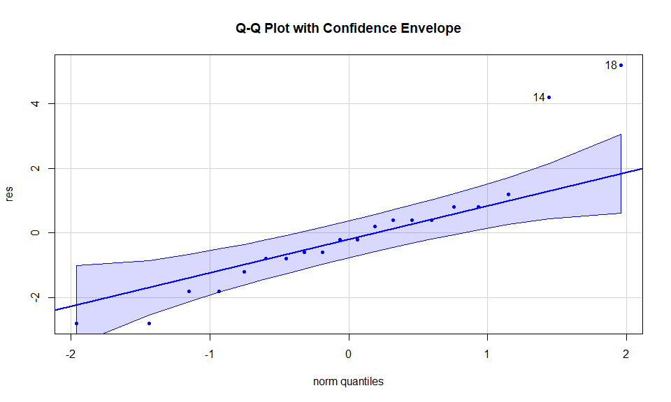

```
[1] 18 14
```

```r
library(car)
qqPlot(res,
       main = "Q-Q Plot with Confidence Envelope",
       col = "blue",
       pch = 20,
       envelope = 0.95)  # 95% confidence envelope
```

```r
library(nortest)
t1 <- ks.test(res, "pnorm", xb, sx);t1
```

```
    Asymptotic one-sample Kolmogorov-Smirnov test

data:  res
D = 0.1922, p-value = 0.4509
alternative hypothesis: two-sided
```

```r
t2 <- lillie.test(res);t2
```

```
    Lilliefors (Kolmogorov-Smirnov) normality test

data:  res
D = 0.1922, p-value = 0.05114
```

```r
t3 <- cvm.test(res);t3
```

```
    Cramer-von Mises normality test

data:  res
W = 0.12333, p-value = 0.04916
```

```r
t4 <- shapiro.test(res);t4
```

```
    Shapiro-Wilk normality test

data:  res
W = 0.88533, p-value = 0.02209
```

```r
t5 <- sf.test(res);t5
```

```
    Shapiro-Francia normality test

data:  res
W = 0.8772, p-value = 0.01788
```

```r
t6 <- ad.test(res);t6
```

```
    Anderson-Darling normality test

data:  res
A = 0.8124, p-value = 0.02928
```

```r
tests <- c(t1$method, t2$method, t3$method,
            t4$method, t5$method, t6$method)
st <- as.numeric(c(t1$statistic, t2$statistic, t3$statistic,
                     t4$statistic, t5$statistic, t6$statistic))
pv <- c(t1$p.value, t2$p.value, t3$p.value,
            t4$p.value, t5$p.value, t6$p.value)

results <- data.frame(Test = tests, Statistic = st, P_Value = pv)
knitr::kable(results)
```

| Test | Statistic | P_Value |
| --- | --- | --- |
| Asymptotic one-sample Kolmogorov-Smirnov test | 0.1921989 | 0.4509444 |
| Lilliefors (Kolmogorov-Smirnov) normality test | 0.1921989 | 0.0511444 |
| Cramer-von Mises normality test | 0.1233347 | 0.0491571 |
| Shapiro-Wilk normality test | 0.8853341 | 0.0220946 |
| Shapiro-Francia normality test | 0.8771952 | 0.0178806 |
| Anderson-Darling normality test | 0.8124019 | 0.0292768 |

**2.2. Homocedasticity test**

```r
bartlett.test(res, data$trat)
```

```
    Bartlett test of homogeneity of variances

data:  res and data$trat
Bartlett's K-squared = 12.141, df = 3, p-value = 0.006914
```

**2.3. Independence test**

[figure not shown]

```r
plot(res,
     type = "b",
     pch = 20,
     col = "blue",
     xlab = "Observation Order",
     ylab = "Residuals",
     main = "Residuals in Order of Collection")
abline(h = 0, col = "red", lty = 2)
```

Does it say something?

### 3. Data transformation

**Which transformation should be used?**

When the statistical data comes from counts, it generally follows the *Poisson* distribution, where the mean and variance are equal. In this case, the square root transformation of the data stabilizes the variance, making it independent of the mean. This transformation can also be used when the variance is proportional to the mean.

```r
n_est_transf <- sqrt(data$n.est + 0.5)
data_tr <- data.frame(coleta = data$coleta,
                      trat = data$trat,
                      n_est_transf = n_est_transf); data_tr
```

```
   coleta trat n_est_transf
1       1    A    1.5811388
2       5    A    1.5811388
3       9    A    1.2247449
4      13    A    1.2247449
5      17    A    0.7071068
6       2    B    1.2247449
7       6    B    0.7071068
8      10    B    0.7071068
9      14    B    1.2247449
10     18    B    1.2247449
11      3    C    3.5355339
12      7    C    3.2403703
13     11    C    3.8078866
14     15    C    4.1833001
15     19    C    3.3911650
16      4    D    2.7386128
17      8    D    3.0822070
18     12    D    3.9370039
19     16    D    2.9154759
20     20    D    3.2403703
```

```r
knitr::kable(data_tr)
```

| coleta | trat | n_est_transf |
| --- | --- | --- |
| 1 | A | 1.5811388 |
| 5 | A | 1.5811388 |
| 9 | A | 1.2247449 |
| 13 | A | 1.2247449 |
| 17 | A | 0.7071068 |
| 2 | B | 1.2247449 |
| 6 | B | 0.7071068 |
| 10 | B | 0.7071068 |
| 14 | B | 1.2247449 |
| 18 | B | 1.2247449 |
| 3 | C | 3.5355339 |
| 7 | C | 3.2403703 |
| 11 | C | 3.8078866 |
| 15 | C | 4.1833001 |
| 19 | C | 3.3911650 |
| 4 | D | 2.7386128 |
| 8 | D | 3.0822070 |
| 12 | D | 3.9370039 |
| 16 | D | 2.9154759 |
| 20 | D | 3.2403703 |

Calculation of means and variances of *n.est* transformed by treatment

```r
mean.est.transf <- tapply(n_est_transf, data$trat, mean); mean.est.transf
```

```
       A        B        C        D
1.263775 1.017690 3.631651 3.182734
```

```r
var.est.transf <- tapply(n_est_transf, data$trat, var); var.est.transf
```

```
         A          B          C          D
0.12859145 0.08038476 0.13888707 0.21275532
```

Veryfing the residual variance from the transformated data

```r
fit2 <- aov(n_est_transf~data$trat)
anova(fit2)
```

```
Analysis of Variance Table

Response: n_est_transf
          Df  Sum Sq Mean Sq F value    Pr(>F)
data$trat  3 26.3394  8.7798  62.644 4.623e-09 ***
Residuals 16  2.2425  0.1402
---
Signif. codes:  0 '***' 0.001 '**' 0.01 '*' 0.05 '.' 0.1 ' ' 1
```

```r
res2 <- fit2$residuals; res2
```

```
          1           2           3           4           5           6
 0.31736399  0.31736399 -0.03902997 -0.03902997 -0.55666806  0.20705524
          7           8           9          10          11          12
-0.31058285 -0.31058285  0.20705524  0.20705524 -0.09611728 -0.39128084
         13          14          15          16          17          18
 0.17623537  0.55164895 -0.24048619 -0.44412122 -0.10052700  0.75426993
         19          20
-0.26725806  0.05763634
```

```r
xb <- mean(res2)
sx <- sd(res2)
```

Error nomality verification

```r
nsim <- 500 # Number os observation
conf <- 0.95 # Conf of reability
```

We perform simulations to compare the observed residuals with the confidence envelope expected under the assumption of normality

```r
datasim <- matrix(rnorm(n * nsim, mean = xb, sd = sx), nrow = n)
datasim <- apply(datasim, 2, sort)

infsup <- apply(datasim, 1, quantile,
                probs = c((1 - conf) / 2,(1 + conf) / 2))

xbsim <- rowMeans(datasim); xbsim
```

```
 [1] -0.64189016 -0.48662831 -0.38600681 -0.31745971 -0.25803596 -0.20596305
 [7] -0.15664138 -0.11294196 -0.06963034 -0.02639372  0.02153000  0.06500854
[13]  0.10915766  0.15532834  0.20489054  0.26217330  0.31964077  0.39064304
[19]  0.49449843  0.65060322
```

Residuals normality distribuition

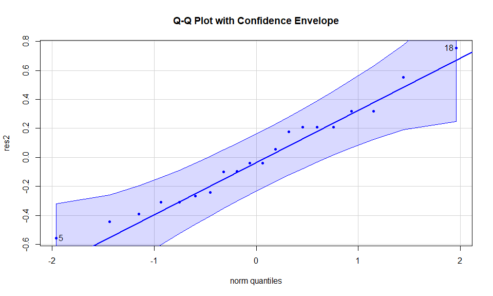

```
[1] 18  5
```

```r
library(car)

qqPlot(res2,
       main = "Q-Q Plot with Confidence Envelope",
       col = "blue",
       pch = 20,
       envelope = 0.95)
```

Verify using statistics numbers

```r
shapiro.test(res2)
```

```
    Shapiro-Wilk normality test

data:  res2
W = 0.97048, p-value = 0.765
```

Checking the homoscedasticity of residuals by Bartlett test

```r
bartlett.test(res2, data_tr$trat)
```

```
    Bartlett test of homogeneity of variances

data:  res2 and data_tr$trat
Bartlett's K-squared = 0.84667, df = 3, p-value = 0.8383
```

Checking the independence of the residual

Residual vs. order of collection of the response variable values plot data

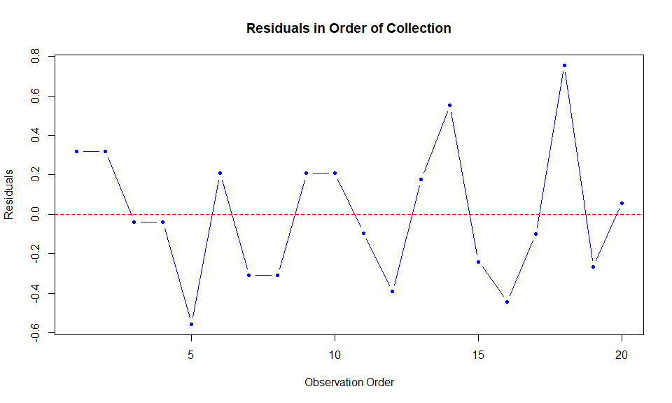

```r
# Se 'res2' é o vetor de resíduos e 'data$coleta' indica a ordem de coleta
plot(res2,
     type = "b",
     pch = 20,
     col = "blue",
     xlab = "Observation Order",
     ylab = "Residuals",
     main = "Residuals in Order of Collection")
abline(h = 0, col = "red", lty = 2)
```

```r
da <- data.frame(data_tr$coleta,res2)
da1 <- da[order(data_tr$coleta, decreasing=F),]
```

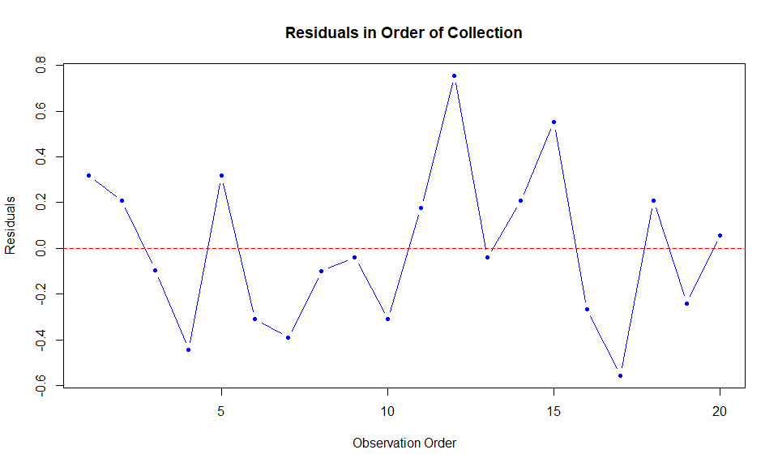

```r
plot(da1$res2,
     type = "b",
     pch = 20,
     col = "blue",
     xlab = "Observation Order",
     ylab = "Residuals",
     main = "Residuals in Order of Collection")
abline(h = 0, col = "red", lty = 2)
```

```r
fit3 <- aov(data_tr$n_est_transf ~ data_tr$trat)
summary(fit3)
```

```
             Df Sum Sq Mean Sq F value   Pr(>F)
data_tr$trat  3 26.339    8.78   62.64 4.62e-09 ***
Residuals    16  2.242    0.14
---
Signif. codes:  0 '***' 0.001 '**' 0.01 '*' 0.05 '.' 0.1 ' ' 1
```

```r
require(ExpDes.pt)
fit4 <- dic(data_tr$trat, data_tr$n_est_trans,
            quali = TRUE, mcomp = "snk", sigT = 0.05, sigF = 0.05)
```

```
------------------------------------------------------------------------
Quadro da analise de variancia
------------------------------------------------------------------------
           GL      SQ     QM     Fc      Pr>Fc
Tratamento  3 26.3394 8.7798 62.644 4.6231e-09
Residuo    16  2.2425 0.1402
Total      19 28.5819
------------------------------------------------------------------------
CV = 16.46 %

------------------------------------------------------------------------
Teste de normalidade dos residuos ( Shapiro-Wilk )
Valor-p:  0.7649626
De acordo com o teste de Shapiro-Wilk a 5% de significancia, os residuos podem ser considerados normais.
------------------------------------------------------------------------

------------------------------------------------------------------------
Teste de homogeneidade de variancia
valor-p:  0.838274
De acordo com o teste de bartlett a 5% de significancia, as variancias podem ser consideradas homogeneas.
------------------------------------------------------------------------

Teste de Student-Newman-Keuls (SNK)
------------------------------------------------------------------------
Grupos  Tratamentos  Medias
a    C       3.631651
a    D       3.182734
 b   A       1.263775
 b   B       1.01769
------------------------------------------------------------------------
```